# Tiña inguinal

Octubre 2021.

## Aspectos generales.

Tiña = Dermatofitosis = Micosis de **piel** y **anexos**.

## Sinonimia.

- Tiña.
- *Tinea*.
- Dermatofisia.
- Dermatofitosis.
- Epidermoficia.
- Epidermofitosis.

Las tiñas son causadas por **dermatofitos**.

## Dermatofitos.

- Hongos filamentosos.
- Queratinofílicos.
- Queratinolíticos.

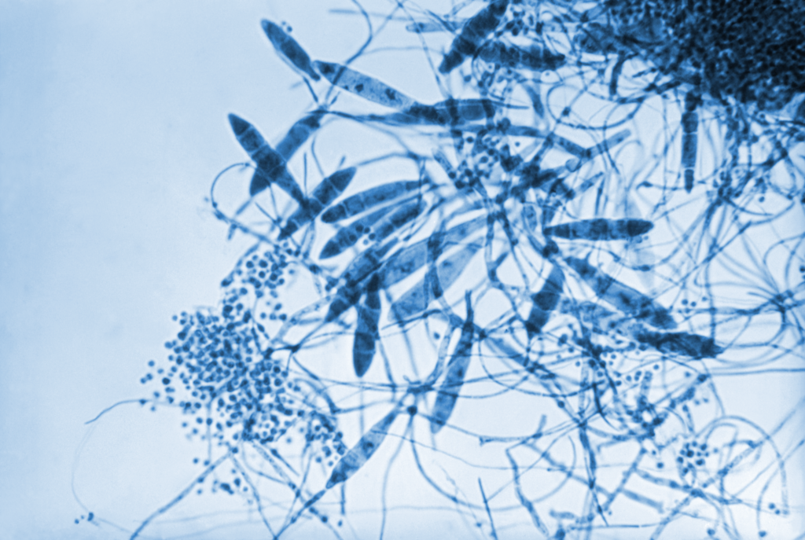

## Tiña inguinal.

Tiña inguinal = ¿?

## Tiña inguinal.

1. Micosis en la **ingle**.
2. Infección causada por hongos microscópicos y filamentosos, los cuales se alimentan de un tipo de proteína epitelial de la piel que pueden metabolizar, y cuya afección se localiza en la **ingle**.
3. Infección causada por dermatofitos localizada en la **ingle**.
4. Dermatofitosis en la **ingle**.

## Sinonimia.

- Tiña de la ingle.
- Tiña crural.
- Epidermofitia inguinal.
- Eczema marginado de Hebra.

*Tinea cruris* | *Tinea inguinalis*

CIE-10 **B35.6**

https://icd.who.int/browse10

## Aspectos epidemiológicos.

- Cosmopolita.
- Clímas cálidos y húmedos.
- Frecuente en verano.
- Ambos sexos. Más en varones (3:1).
- Más común en adultos, especialmente sedentarios.
- Correlación positiva con otras dermatrofitosis.
- No hay susceptibilidad de etnia.

## Etiología.

- Agentes causales.
  - *T. rubrum*.
  - *E. floccosum*.
  - *T. mentagrophytes* var. *interdigitale*.
  - *T. verrucosum*.

## Mecanismos de transmisión.

- Autoinfección.
- Contacto de persona a persona.
- A través de fomites.

## Patogenia.

1. Contacto espora-piel.
2. Pápula eritematosa o vesícula con prurito.
3. Producción y digestión de queratina.
4. Placas eritemato-escamosas.
5. Extensión a través de los pliegues inguinales.

## Aspectos clínicos.

- Placa anular, borde elevado y escamoso.
- Del pliegue inguinal a la cara interna del muslo.
- Forma bilateral.
- Placas eritematosas y escamosas.
  - Pápulas.
  - Vesículas.
- Prurito.
- Dolor al macerar las placas.

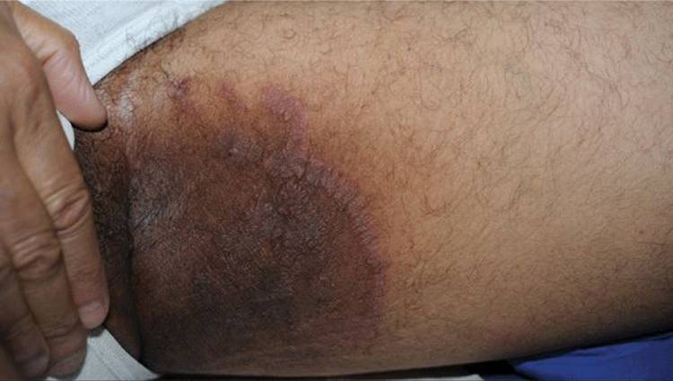

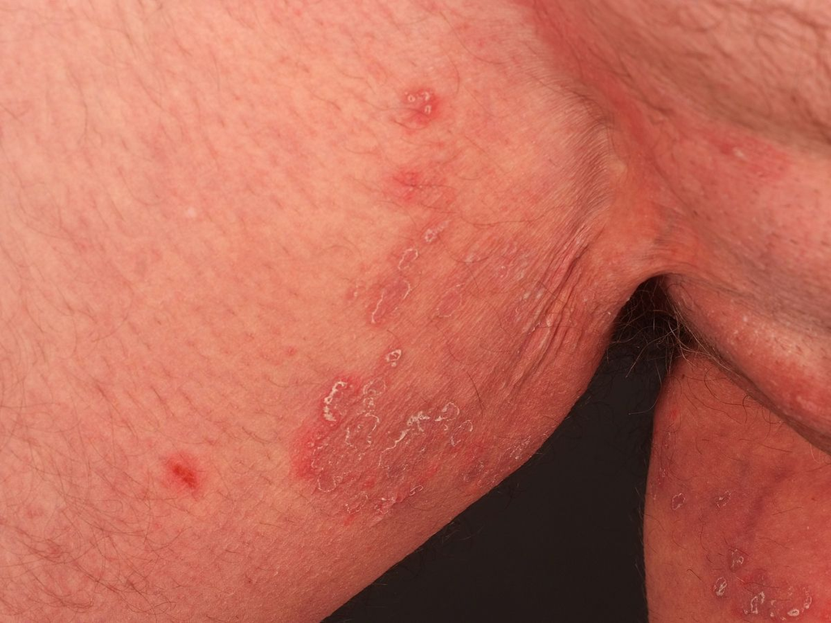

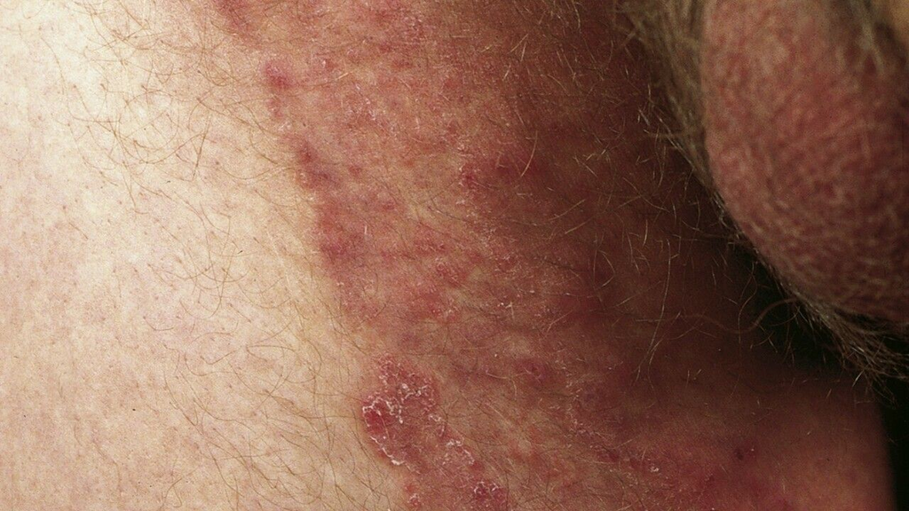

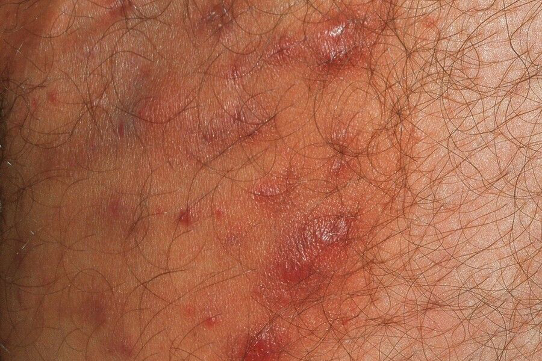

## Diagnóstico.

- Exploración médica.
- Exámenes.
  - Prueba de hidróxido de potasio (KOH).
  - Prueba de cultivo fúngico.
  - Biopsia.
  - Inmunofluorescencia.

## Diagnóstico diferencial.

- Eritrasma.
- Intertrigo por *Candida*.
- Psoriasis inversa.
- Pitiriasis versicolor.

## Tratamiento.

- Antimicóticos.
  - Sulconazol, Oxiconazol, Miconazol, Clotrimazol, Econazol, Ketoconazol, Efinaconazol, Naftifina, Ciclopiroxolamina, Terbinafina y Butenafina.
- Ventilación del área afectada.
- Talco.
  - Común.
  - Antimicótico.

## Profilaxis.

- Evitar el contacto con:
  - personas infectadas.
  - ropa y accesorios de otras personas.
  - la ingle, si se tuvo contacto con una zona infectada.
- Barreras o mecanismos que eviten la autoinfección.

## Bibliografía.

Altmeyer, Prof. Dr. med. P. (2020). Tinea INGUINALIS - ALTMEYERS encyclopedia - department dermatology. In *Tinea inguinalis - Altmeyers Encyclopedia - Department Dermatology*. Altmeyers Encyclopedia. https://www.altmeyers.org/en/dermatology/tinea-inguinalis-121416

Bonifaz, J. A. (2012). *Micología médica básica* (4th ed.). McGraw-Hill Interamericana Editores, S. A. de C. V.

James, W. D., Elston, D. M., Treat, J. R., Rosenbach, M. A., & Neuhaus, I. M. (2020). *Andrews’ diseases of the skin. Clinical dermatology* (13th ed.). Elsevier.

Kang, S., Amagai, M., Bruckner, A. L., Enk, A. H., Margolis, D. J., McMichael, A. J., & Orringer, J. S. (2019). *Fitzpatrick’s dermatology* (9th ed., Vol. 2). McGraw-Hill Education.

Wolff, K., Johnson, R. A., Saavedra, A. P., & Roh, E. K. (2017). *Fitzpatrick’s color atlas and sinopsis of clinical dermatology* (8th ed.). McGraw-Hill Education.